# Bellabeat

Adewunmmi Oluwaseun

2022-07-09

## BELLABEAT CASE STUDY

### ABOUT THE COMPANY

*Urška Sršen and Sando Mur founded Bellabeat, a high-tech company that manufactures health-focused smart products. Sršen used her background as an artist to develop beautifully designed technology that informs and inspires women around the world. Collecting data on activity, sleep, stress, and reproductive health has allowed Bellabeat to empower women with knowledge about their own health and habits. Since it was founded in 2013, Bellabeat has grown rapidly and quickly positioned itself as a tech-driven wellness company for women. By 2016, Bellabeat had opened offices around the world and launched multiple products. Bellabeat products became available through a growing number of online retailers in addition to their own e-commerce channel on their website. The company has invested in traditional advertising media, such as radio, out-of-home billboards, print, and television, but focuses on digital marketing extensively. Bellabeat invests year-round in Google Search, maintaining active Facebook and Instagram pages, and consistently engages consumers on Twitter. Additionally, Bellabeat runs video ads on Youtube and display ads on the Google Display Network to support campaigns around key marketing dates. Sršen knows that an analysis of Bellabeat’s available consumer data would reveal more opportunities for growth. She has asked the marketing analytics team to focus on a Bellabeat product and analyze smart device usage data in order to gain insight into how people are already using their smart devices. Then, using this information, she would like high-level recommendations for how these trends can inform Bellabeat marketing strategy.*

### BUSINESS TASK

Sršen asked me as an analyst to:

- Help analyze smart device usage data gotten from public dataset Fitbit Fitness Tracker Data available on Kaggle to gain insight into how consumers use non-Bellabeat smart devices to help guide marketing strategy for the company.
- Select one Bellabeat product to apply insights gotten to and present findings thereafter.

### STAKEHOLDERS

- Urška Sršen- Bellabeat’s cofounder and Chief Creative Officer
- Sando Mur- Mathematician and Bellabeat’s cofounder; key member of the Bellabeat executive team
- Bellabeat marketing analytics team: A team of data analysts responsible for collecting, analyzing, and reporting data that helps guide Bellabeat’s marketing strategy.

### BELLABEAT PRODUCTS

- **Bellabeat app:** The Bellabeat app provides users with health data related to their activity, sleep, stress, menstrual cycle, and mindfulness habits. This data can help users better understand their current habits and make healthy decisions. The Bellabeat app connects to their line of smart wellness products.
- **Leaf:** Bellabeat’s classic wellness tracker can be worn as a bracelet, necklace, or clip. The Leaf tracker connects to the Bellabeat app to track activity, sleep, and stress.
- **Time:** This wellness watch combines the timeless look of a classic timepiece with smart technology to track user activity, sleep, and stress. The Time watch connects to the Bellabeat app to provide you with insights into your daily wellness.
- **Spring:** This is a water bottle that tracks daily water intake using smart technology to ensure that you are appropriately hydrated throughout the day. The Spring bottle connects to the Bellabeat app to track your hydration levels.
- **Bellabeat membership:** Bellabeat also offers a subscription-based membership program for users. Membership gives users 24/7 access to fully personalized guidance on nutrition, activity, sleep, health and beauty, and mindfulness based on their lifestyle and goals.

### ASK PHASE

*Here I’m looking to jot down potential questions I’m looking to answer with the data available to me.* - What are some trends and patterns I can detect in the smart device usage? - How could these trends apply to Bellabeat customers? - How could these trends help influence Bellabeat marketing strategy? Going forward these questions above would serve as my guide, and I will be walking you through my thought process and step-by-step analysis towards answering those questions.

### PREPARE PHASE

*Here I will be looking to collect our data, organize, sort, filter and prepare it for analysis.*

#### LICENSING, PRIVACY, SECURITY AND ACCESSIBILITY

- The dataset used for this analysis was sourced from (CC0: Public Domain, dataset made available through [Mobius](https://www.kaggle.com/arashnic)), It is open source, open for any and anyone to access, modify, reuse and share.
- The data is organized in a long format with separate rows representing different days in the span of activity
- Even though the data is from a reliable source and it is cited, while exploring the dataset I found out there are quite a few limitations to the dataset

  1. ```
     it is not current and the one-month time frame (April-May) is not enough time period to track consistent habits amongst consumers.
     ```

  2. ```
     it is hard to check for sampling bias as there are no demographic information tied to each user id to compare age, sex, location e.t.c
     ```

### PROCESS PHASE

*This is where we get to process our data for analysis*

```
##                     User_Id   Days_of_Inactivity
## 1                2347167796              13 days
## 2                3372868164              11 days
## 3 4020332650 and 1927972279 14 days respectively
## 4                4057192912    26 days (Outlier)
## 5 8253242879 and 8792009665 12 days respectively
## 6                1844505072              10 days
```

- Other users completed at least 27 days of tracking their activities on the app.
- After exploring all of the 18 CSV files present in our dataset, I settled for 4 of the files containing data sufficient to tackle our business task. **FILES CHOSEN**
  - dailyActivity_merged.csv
  - dailyIntensities_merged.csv
  - sleepDay_merged.csv
  - hourlySteps_merged.csv

    N.B The weightLogInfo_merged.csv would have also been a good pick but it only contained weight info for 8 of the 33 unique ID’s found in the dataset, forcing me to drop it.

Loading libraries for data cleaning and analysis……

```r
library(tidyverse)
library(readr)
library(lubridate)
library(skimr)
library(psych)
library(janitor)
```

We read in our datasets

```r
daily_activity <- read.csv('dailyActivity_merged.csv')
daily_intensity <- read.csv('dailyIntensities_merged.csv')
hourly_steps <- read.csv('hourlySteps_merged.csv')
sleep_day <- read.csv('sleepDay_merged.csv')
```

After which we preview our datasets to get a general overview

```r
head(daily_activity)
```

```
##           Id ActivityDate TotalSteps TotalDistance TrackerDistance
## 1 1503960366    4/12/2016      13162          8.50            8.50
## 2 1503960366    4/13/2016      10735          6.97            6.97
## 3 1503960366    4/14/2016      10460          6.74            6.74
## 4 1503960366    4/15/2016       9762          6.28            6.28
## 5 1503960366    4/16/2016      12669          8.16            8.16
## 6 1503960366    4/17/2016       9705          6.48            6.48
##   LoggedActivitiesDistance VeryActiveDistance ModeratelyActiveDistance
## 1                        0               1.88                     0.55
## 2                        0               1.57                     0.69
## 3                        0               2.44                     0.40
## 4                        0               2.14                     1.26
## 5                        0               2.71                     0.41
## 6                        0               3.19                     0.78
##   LightActiveDistance SedentaryActiveDistance VeryActiveMinutes
## 1                6.06                       0                25
## 2                4.71                       0                21
## 3                3.91                       0                30
## 4                2.83                       0                29
## 5                5.04                       0                36
## 6                2.51                       0                38
##   FairlyActiveMinutes LightlyActiveMinutes SedentaryMinutes Calories
## 1                  13                  328              728     1985
## 2                  19                  217              776     1797
## 3                  11                  181             1218     1776
## 4                  34                  209              726     1745
## 5                  10                  221              773     1863
## 6                  20                  164              539     1728
```

```r
head(daily_intensity)
```

```
##           Id ActivityDay SedentaryMinutes LightlyActiveMinutes
## 1 1503960366   4/12/2016              728                  328
## 2 1503960366   4/13/2016              776                  217
## 3 1503960366   4/14/2016             1218                  181
## 4 1503960366   4/15/2016              726                  209
## 5 1503960366   4/16/2016              773                  221
## 6 1503960366   4/17/2016              539                  164
##   FairlyActiveMinutes VeryActiveMinutes SedentaryActiveDistance
## 1                  13                25                       0
## 2                  19                21                       0
## 3                  11                30                       0
## 4                  34                29                       0
## 5                  10                36                       0
## 6                  20                38                       0
##   LightActiveDistance ModeratelyActiveDistance VeryActiveDistance
## 1                6.06                     0.55               1.88
## 2                4.71                     0.69               1.57
## 3                3.91                     0.40               2.44
## 4                2.83                     1.26               2.14
## 5                5.04                     0.41               2.71
## 6                2.51                     0.78               3.19
```

```r
head(hourly_steps)
```

```
##           Id          ActivityHour StepTotal
## 1 1503960366 4/12/2016 12:00:00 AM       373
## 2 1503960366  4/12/2016 1:00:00 AM       160
## 3 1503960366  4/12/2016 2:00:00 AM       151
## 4 1503960366  4/12/2016 3:00:00 AM         0
## 5 1503960366  4/12/2016 4:00:00 AM         0
## 6 1503960366  4/12/2016 5:00:00 AM         0
```

```r
head(sleep_day)
```

```
##           Id              SleepDay TotalSleepRecords TotalMinutesAsleep
## 1 1503960366 4/12/2016 12:00:00 AM                 1                327
## 2 1503960366 4/13/2016 12:00:00 AM                 2                384
## 3 1503960366 4/15/2016 12:00:00 AM                 1                412
## 4 1503960366 4/16/2016 12:00:00 AM                 2                340
## 5 1503960366 4/17/2016 12:00:00 AM                 1                700
## 6 1503960366 4/19/2016 12:00:00 AM                 1                304
##   TotalTimeInBed
## 1            346
## 2            407
## 3            442
## 4            367
## 5            712
## 6            320
```

Check for number of unique Id’s

```r
n_unique(daily_activity$Id)
```

```
## [1] 33
```

```r
n_unique(daily_intensity$Id)
```

```
## [1] 33
```

```r
n_unique(hourly_steps$Id)
```

```
## [1] 33
```

```r
n_unique(sleep_day$Id)
```

```
## [1] 24
```

Check for duplicates

```r
sum(duplicated(daily_activity))
```

```
## [1] 0
```

```r
sum(duplicated(daily_intensity))
```

```
## [1] 0
```

```r
sum(duplicated(hourly_steps))
```

```
## [1] 0
```

```r
sum(duplicated(sleep_day))
```

```
## [1] 3
```

No duplicates found in the first three files but we found 3 duplicates in the sleep_day file, we will proceed to remove duplicates

```r
sleep_day <- sleep_day %>%
  distinct() %>%
  drop_na()
```

Now we confirm the duplicates were truly removed

```r
sum(duplicated(sleep_day))
```

```
## [1] 0
```

Now we proceed to the days of inactivity, days of inactivity equal days where the total steps taken equal zero or the sedantary minutes equal 1440, this might be due to different factors maybe the users forgot to track their activities, forgot their device at home, low batter or they just didn’t charge it.

```r
daily_activity <-  filter(daily_activity, TotalSteps != 0)
daily_intensity <- filter(daily_intensity, SedentaryMinutes != 1440)
```

Having done that, we proceed to inspect the structure of our data and ensure they are in the right format suitable for analysis.

```r
str(daily_activity)
```

```
## 'data.frame':    863 obs. of  15 variables:
##  $ Id                      : num  1.5e+09 1.5e+09 1.5e+09 1.5e+09 1.5e+09 ...
##  $ ActivityDate            : chr  "4/12/2016" "4/13/2016" "4/14/2016" "4/15/2016" ...
##  $ TotalSteps              : int  13162 10735 10460 9762 12669 9705 13019 15506 10544 9819 ...
##  $ TotalDistance           : num  8.5 6.97 6.74 6.28 8.16 ...
##  $ TrackerDistance         : num  8.5 6.97 6.74 6.28 8.16 ...
##  $ LoggedActivitiesDistance: num  0 0 0 0 0 0 0 0 0 0 ...
##  $ VeryActiveDistance      : num  1.88 1.57 2.44 2.14 2.71 ...
##  $ ModeratelyActiveDistance: num  0.55 0.69 0.4 1.26 0.41 ...
##  $ LightActiveDistance     : num  6.06 4.71 3.91 2.83 5.04 ...
##  $ SedentaryActiveDistance : num  0 0 0 0 0 0 0 0 0 0 ...
##  $ VeryActiveMinutes       : int  25 21 30 29 36 38 42 50 28 19 ...
##  $ FairlyActiveMinutes     : int  13 19 11 34 10 20 16 31 12 8 ...
##  $ LightlyActiveMinutes    : int  328 217 181 209 221 164 233 264 205 211 ...
##  $ SedentaryMinutes        : int  728 776 1218 726 773 539 1149 775 818 838 ...
##  $ Calories                : int  1985 1797 1776 1745 1863 1728 1921 2035 1786 1775 ...
```

```r
str(daily_intensity)
```

```
## 'data.frame':    861 obs. of  10 variables:
##  $ Id                      : num  1.5e+09 1.5e+09 1.5e+09 1.5e+09 1.5e+09 ...
##  $ ActivityDay             : chr  "4/12/2016" "4/13/2016" "4/14/2016" "4/15/2016" ...
##  $ SedentaryMinutes        : int  728 776 1218 726 773 539 1149 775 818 838 ...
##  $ LightlyActiveMinutes    : int  328 217 181 209 221 164 233 264 205 211 ...
##  $ FairlyActiveMinutes     : int  13 19 11 34 10 20 16 31 12 8 ...
##  $ VeryActiveMinutes       : int  25 21 30 29 36 38 42 50 28 19 ...
##  $ SedentaryActiveDistance : num  0 0 0 0 0 0 0 0 0 0 ...
##  $ LightActiveDistance     : num  6.06 4.71 3.91 2.83 5.04 ...
##  $ ModeratelyActiveDistance: num  0.55 0.69 0.4 1.26 0.41 ...
##  $ VeryActiveDistance      : num  1.88 1.57 2.44 2.14 2.71 ...
```

```r
str(hourly_steps)
```

```
## 'data.frame':    22099 obs. of  3 variables:
##  $ Id          : num  1.5e+09 1.5e+09 1.5e+09 1.5e+09 1.5e+09 ...
##  $ ActivityHour: chr  "4/12/2016 12:00:00 AM" "4/12/2016 1:00:00 AM" "4/12/2016 2:00:00 AM" "4/12/2016 3:00:00 AM" ...
##  $ StepTotal   : int  373 160 151 0 0 0 0 0 250 1864 ...
```

```r
str(sleep_day)
```

```
## 'data.frame':    410 obs. of  5 variables:
##  $ Id                : num  1.5e+09 1.5e+09 1.5e+09 1.5e+09 1.5e+09 ...
##  $ SleepDay          : chr  "4/12/2016 12:00:00 AM" "4/13/2016 12:00:00 AM" "4/15/2016 12:00:00 AM" "4/16/2016 12:00:00 AM" ...
##  $ TotalSleepRecords : int  1 2 1 2 1 1 1 1 1 1 ...
##  $ TotalMinutesAsleep: int  327 384 412 340 700 304 360 325 361 430 ...
##  $ TotalTimeInBed    : int  346 407 442 367 712 320 377 364 384 449 ...
```

Seeing all the dates in the dataset are all formatted as character we will correct that by formatting as date

```r
daily_activity <- daily_activity %>%
  mutate(ActivityDate = as_date(ActivityDate, format = '%m/%d/%y'))
daily_intensity <- daily_intensity %>%
  mutate(ActivityDay = as_date(ActivityDay, format = '%m/%d/%y'))
hourly_steps <- hourly_steps %>%
  mutate(ActivityHour = as.POSIXct(ActivityHour,format ="%m/%d/%Y %I:%M:%S %p" , tz=Sys.timezone()))
sleep_day <- sleep_day %>%
  mutate(SleepDay = as.POSIXct(SleepDay,format ="%m/%d/%Y %I:%M:%S %p" , tz=Sys.timezone()))
```

Lastly we will like to clean and rename our columns for consistency

```r
daily_activity <- clean_names(daily_activity)
daily_intensity <- clean_names(daily_intensity)
hourly_steps <- clean_names(hourly_steps)
sleep_day <- clean_names(sleep_day)
```

### ANALYZE PHASE

*This is the phase where we get to do the analysis*

*We will have to deal with the limitations in the data by classifying the users into demographics according to their level of activity as we have not been provided with any demographic or categorical variable*

We will be settling with the following classifications according to the following article published by [medicinet.com](https://www.medicinenet.com/how_many_steps_a_day_is_considered_active/article.htm) with slight modifications

- **Sedentary:** Less than 5,000 steps daily
- **Low Active:** About 5,000 to 7,499 steps daily
- **Somewhat Active:** About 7,500 to 9,999 steps daily
- **Highly Active:** More than 10,000 steps daily

Now to classify our users we will try to get each users average step by their id.

```r
daily_average <- daily_activity %>%
  group_by(id) %>%
  summarise(average_steps = mean(total_steps), average_calories = mean(calories), average_sedentary = mean(sedentary_minutes))
head(daily_average)
```

```
## # A tibble: 6 × 4
##           id average_steps average_calories average_sedentary
##        <dbl>         <dbl>            <dbl>             <dbl>
## 1 1503960366        12521.            1877.              828.
## 2 1624580081         5744.            1483.             1258.
## 3 1644430081         7283.            2811.             1162.
## 4 1844505072         3809.            1714.             1130.
## 5 1927972279         1671.            2303.             1244.
## 6 2022484408        11371.            2510.             1113.
```

Now to classify user activity by average steps taken, calculate percentage distribution.

```r
user_type <- daily_average %>%
  mutate(user_type = case_when(
    average_steps < 5000 ~ "sedentary",
    average_steps >= 5000 & average_steps < 7499 ~ "low active",
    average_steps >= 7500 & average_steps < 9999 ~ "somewhat active",
    average_steps >= 10000 ~ "Highly active"
  ))
percentage_user_type <- user_type %>%
  group_by(user_type) %>%
  summarise(total = n()) %>%
  mutate(totals = sum(total)) %>%
  group_by(user_type) %>%
  summarise(total_percent = total / totals) %>%
  mutate(labels = scales::percent(total_percent))
```

Then we visualize the user percentage using a pie chart

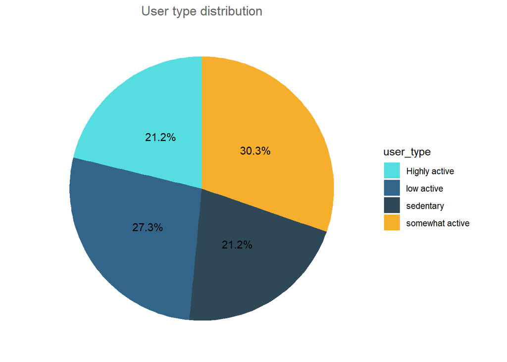

```r
percentage_user_type %>%
  ggplot(aes(x="",y=total_percent, fill=user_type)) +
  geom_bar(stat = "identity", width = 1)+
  coord_polar("y", start=0)+
  theme_minimal()+
  theme(axis.title.x= element_blank(),
        axis.title.y = element_blank(),
        panel.border = element_blank(),
        panel.grid = element_blank(),
        axis.ticks = element_blank(),
        axis.text.x = element_blank(),
        plot.title = element_text(hjust = 0.5, color = "#666666")) +
  scale_fill_manual(values = c("#55DDE0", "#33658A", "#2F4858", "#F6AE2D", "#F26419")) +
  geom_text(aes(label = labels),
            position = position_stack(vjust = 0.5))+
  labs(title="User type distribution")
```

We understand from our visual that the users are fairly distributed with the “somewhat active” users holding slight edge. Based on our visuals, we also understand that at least 51.5% of our users walk the recommended 7500 steps per day.

We will like to understand which day of the week our users are mostly inactive by analyzing the average sedantary minutes

```r
#Get Sedantary week day
weekday_inactivity <- daily_activity %>%
  mutate(weekday = weekdays(activity_date))

weekday_inactivity$weekday <- ordered(weekday_inactivity$weekday, levels = c('Monday','Tuesday','Wednesday','Thursday','Friday','Saturday','Sunday'))

weekday_inactivity <- weekday_inactivity %>%
  group_by(weekday) %>%
  summarize (average_sedentary = mean(sedentary_minutes))
head(weekday_inactivity)
```

```
## # A tibble: 6 × 2
##   weekday   average_sedentary
##   <ord>                 <dbl>
## 1 Monday                 954.
## 2 Tuesday                921.
## 3 Wednesday              978.
## 4 Thursday               930.
## 5 Friday                 945.
## 6 Saturday               990.
```

Visualizing that result on a column chart we have

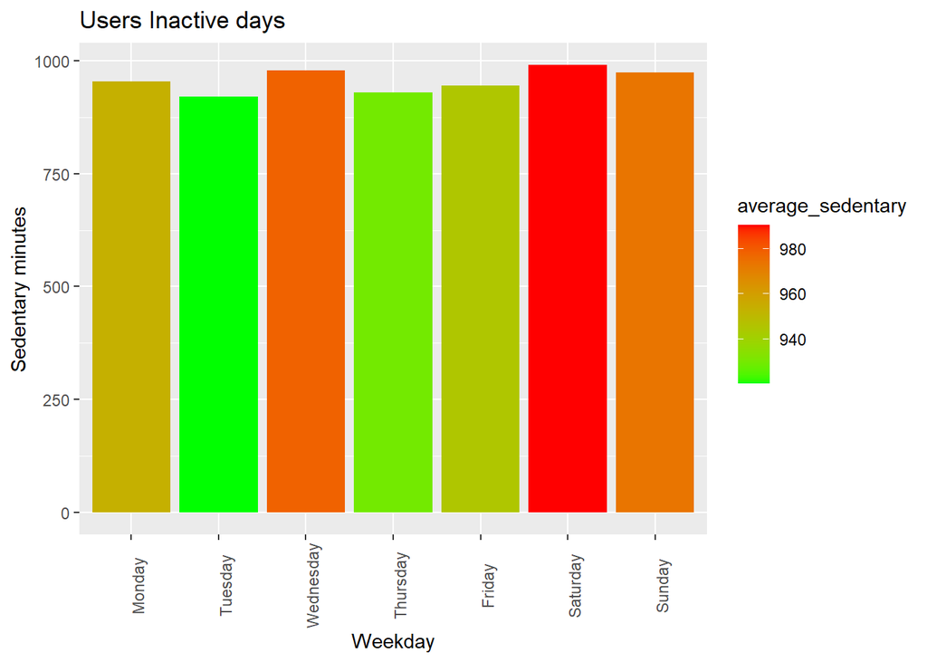

```r
weekday_inactivity %>%
  ggplot() +
  geom_col(mapping = aes(x=weekday, y = average_sedentary, fill = average_sedentary)) +
  labs(title = "Users Inactive days", x="Weekday", y="Sedentary minutes") +
  scale_fill_gradient(low = "green", high = "red")+
  theme(axis.text.x = element_text(angle = 90))
```

If they are in active on weekends then they should be well rested, let’s check that out. First we aggregate our sleep data.

```r
sleepday_activity <- sleep_day %>%
  mutate(weekday = weekdays(sleep_day))

sleepday_activity$weekday <- ordered(sleepday_activity$weekday, levels = c('Monday','Tuesday','Wednesday','Thursday','Friday','Saturday','Sunday'))

sleepday_activity <- sleepday_activity %>%
  group_by(weekday) %>%
  summarize (average_sleep = mean(total_minutes_asleep))
head(sleepday_activity)
```

```
## # A tibble: 6 × 2
##   weekday   average_sleep
##   <ord>             <dbl>
## 1 Monday             420.
## 2 Tuesday            405.
## 3 Wednesday          435.
## 4 Thursday           401.
## 5 Friday             405.
## 6 Saturday           419.
```

We proceed to visualize our findings

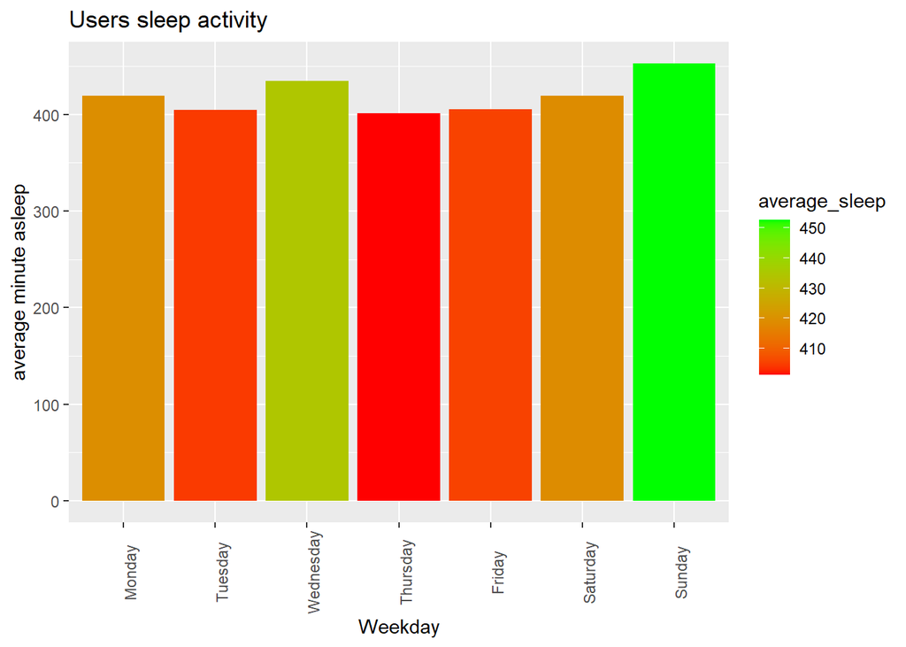

```r
sleepday_activity %>%
  ggplot() +
  geom_col(mapping = aes(x=weekday, y = average_sleep, fill = average_sleep)) +
  labs(title = "Users sleep activity", x="Weekday", y="average minute asleep") +
  scale_fill_gradient(low = "red", high = "green")+
  theme(axis.text.x = element_text(angle = 90))
```

Sunday comes out on top, it is not suprising that our users are getting to rest fully on weekends.

Moving forward we will like to know what hour of the day our users are mostly active to better understand their behaviour throughtout the day

```r
hourly_steps <- hourly_steps %>%
  separate(activity_hour, into = c("date", "time"), sep= " ") %>%
  mutate(date = ymd(date))

head(hourly_steps)
```

```
##           id       date     time step_total
## 1 1503960366 2016-04-12 00:00:00        373
## 2 1503960366 2016-04-12 01:00:00        160
## 3 1503960366 2016-04-12 02:00:00        151
## 4 1503960366 2016-04-12 03:00:00          0
## 5 1503960366 2016-04-12 04:00:00          0
## 6 1503960366 2016-04-12 05:00:00          0
```

We will proceed to represent this information on a column chart

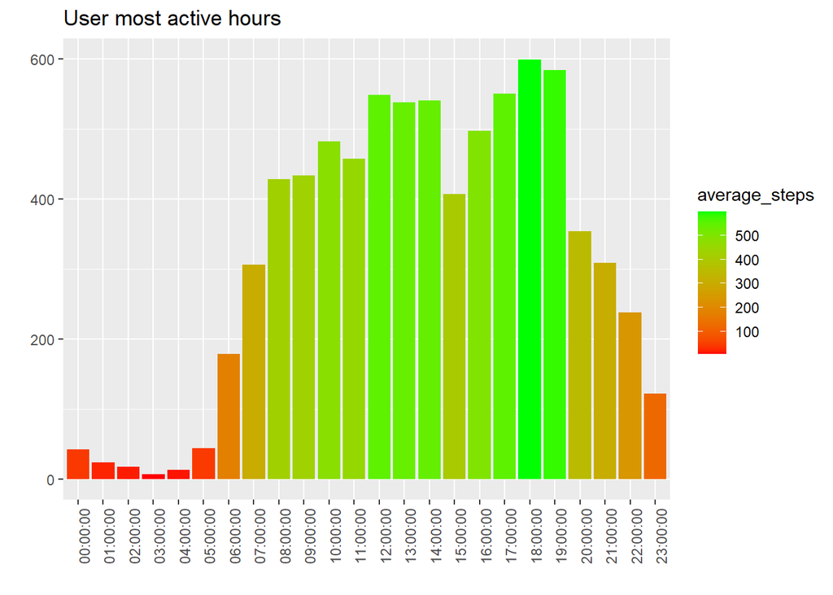

```r
hourly_steps %>%
  group_by(time) %>%
  summarize(average_steps = mean(step_total)) %>%
  ggplot() +
  geom_col(mapping = aes(x=time, y = average_steps, fill = average_steps)) +
  labs(title = "User most active hours", x="", y="") +
  scale_fill_gradient(low = "red", high = "green")+
  theme(axis.text.x = element_text(angle = 90))
```

I will like to know if there is a correlation between number of steps taken and calories expended, likewise the average number of steps taken and minutes spent in bed/taken to rest.

First we generate a correlation matrix

```r
daily_average %>%
  select(average_steps, average_calories) %>%
  cor()
```

```
##                  average_steps average_calories
## average_steps        1.0000000        0.3960166
## average_calories     0.3960166        1.0000000
```

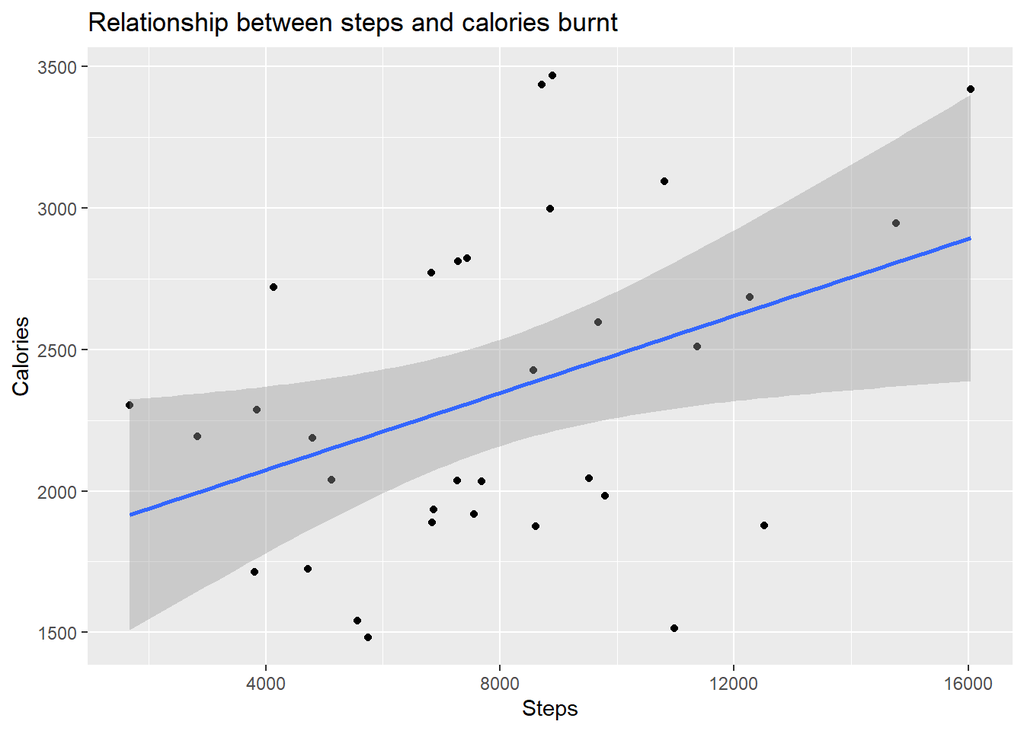

```r
ggplot(data = daily_average, aes(x = average_steps, y = average_calories))+
         geom_point()+
         xlab('Steps') + ylab('Calories')+
        ggtitle('Relationship between steps and calories burnt')+
        geom_smooth(method = lm)
```

We find a weak positive relationship between average number of steps and calories expended. Next we try to get the correlation between sleep and steps taken.

```r
user_sleep <- sleep_day %>%
  group_by(id) %>%
  summarise(average_minute_asleep = mean(total_minutes_asleep))
```

Recall we have just 24 users who recorded their sleep data, which means 9 of our users failed to use their device in bed. we will proceed to join the sleep data with our daily_average data by Id.

```r
daily_average <- daily_average %>%
  left_join(user_sleep)
head(daily_average)
```

```
## # A tibble: 6 × 5
##           id average_steps average_calories average_sedentary average_minute_as…
##        <dbl>         <dbl>            <dbl>             <dbl>              <dbl>
## 1 1503960366        12521.            1877.              828.               360.
## 2 1624580081         5744.            1483.             1258.                NA
## 3 1644430081         7283.            2811.             1162.               294
## 4 1844505072         3809.            1714.             1130.               652
## 5 1927972279         1671.            2303.             1244.               417
## 6 2022484408        11371.            2510.             1113.                NA
```

We then proceed to test the relationship between steps and minutes asleep

```r
daily_average %>%
  select(average_steps, average_minute_asleep) %>%
  drop_na() %>%
  cor()
```

```
##                       average_steps average_minute_asleep
## average_steps             1.0000000            -0.2129543
## average_minute_asleep    -0.2129543             1.0000000
```

```
## Warning: Removed 9 rows containing non-finite values (stat_smooth).
```

```
## Warning: Removed 9 rows containing missing values (geom_point).
```

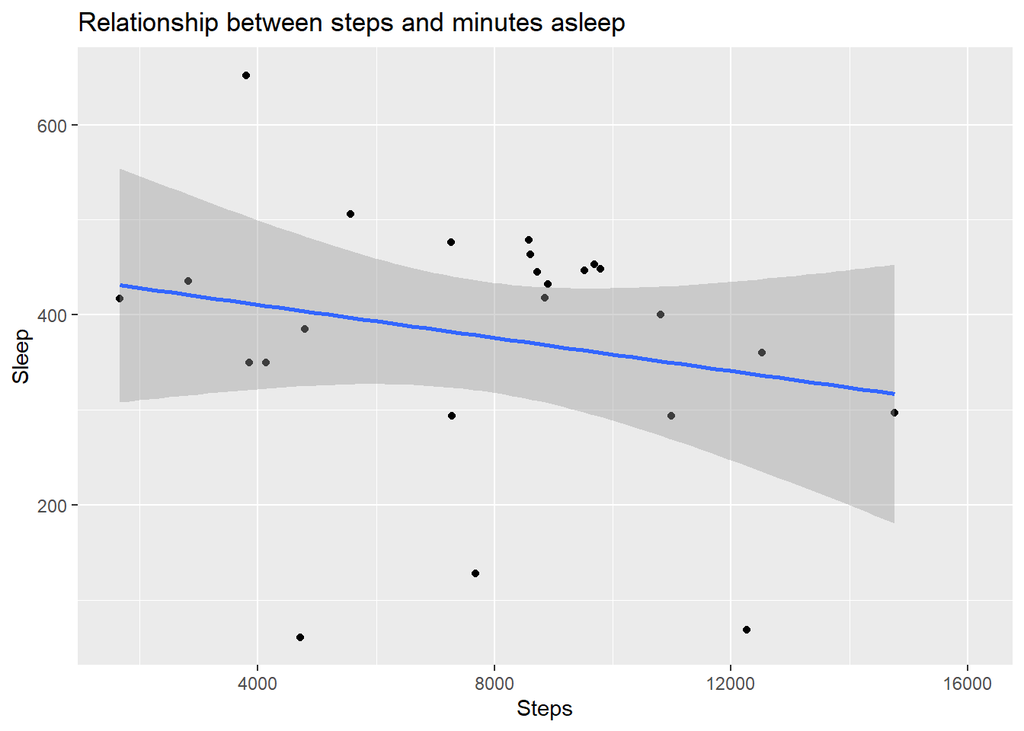

```r
ggplot(data = daily_average, aes(x = average_steps, y = average_minute_asleep))+
  geom_point()+
  xlab('Steps') + ylab('Sleep')+
  ggtitle('Relationship between steps and minutes asleep')+
  geom_smooth(method = lm)
```

We get a warning stating 9rows have been removed, i.e 9 instances where sleep data were not present.

### CONCLUSION (ACT PHASE)

**First i will like to reiterate the limitations of this dataset given the sample size, no demographic data and enumerate possible bias.**

- **BELLA BEAT APP** According to [sleep foundation](https://www.sleepfoundation.org/how-sleep-works/how-much-sleep-do-we-really-need#:~:text=National%20Sleep%20Foundation%20guidelines1,to%208%20hours%20per%20night.) humans are recommended an average of 8 hours sleep per day which equates to about 480 minutes per day, our analysis shows users are not getting the recommended sleep time infact with 452 minutes being the highest, I recommend an in app notification pop up design for the *Bellabeat app* to remind users minutes before their bed time to prepare for bed.
- **BELLA WRISTWATCH** We noticed users are not recording sleep data, this could be due to many factors, like low battery before bed-time, watch design(Is the wristwatch heavy or light?) We recommend Bellabeat focuses on long lasting batteries as their selling point, and a rich ultra modern light weight design so users can use their wristwatch even in bed.